# Coursera_MachLearning

Manuel Kiewisch

Wednesday, July 22, 2015

## Purpose

- predict exercise data from personal activity devices
- predict if available data per exercise has been collected from a ‘’correct’‘or’‘incorrect’’ performance
- report on the model building process and describe the expected out-of-sample error

## Data

- based on the ‘’Groupware’’ data set available at: http://groupware.les.inf.puc-rio.br/har

## Data Preparation

- a training and test data set have been combiled and made available at:
- https://d396qusza40orc.cloudfront.net/predmachlearn/pml-training.csv
- https://d396qusza40orc.cloudfront.net/predmachlearn/pml-testing.csv
- the memory available to R is set to 4gb
- all variables containing missing values have been remove
- further, all purely descriptive variables (variables 1–7, i.e. name, id, timestamps) have been removed since they are not expected to be of any predictive value
- the predictor variable $classe is transformed to a factor variable
- the remaining variables are scanned for near-Zero-Variables and near-Zero-Variables are removed

```
## [1] 4000
```

## Data Splicing

```r
training <- training[sample(nrow(training), 9000), ]
inTrain <- createDataPartition(y=training$classe, p=0.6,list=FALSE)
training <- training[inTrain,]
test <- training[-inTrain,]
```

## Model Building

- a ‘Random Forest’ modeling procedure is used to create the prediction model
- cross-validation is used to select the model with highest accuracy
- pre-processing is used to adjust the remaining variables, including a Principal-Component-Analysis to identify valuable predictor groups
- the following graph displays the result of the principal component analysis for components 1 and 2 for the training data partition

```r
modelfit <- train(classe ~.,method="rf",data=training,trControl=trainControl(method="cv"),preProcess=c("center","scale","pca"),prox=TRUE)
```

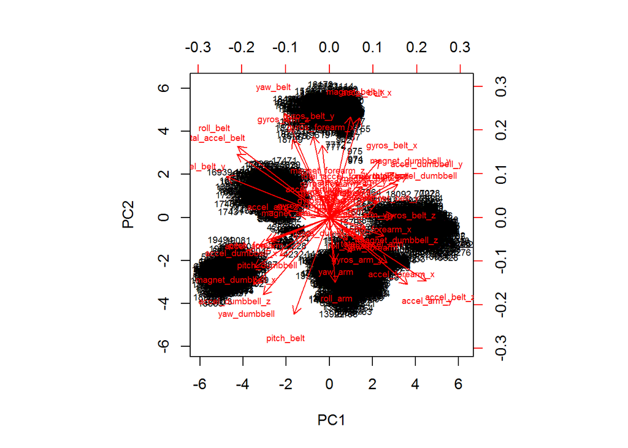

```r
pca <- prcomp(training[, -c(53)], scale.=TRUE)
biplot(pca, scale=0, cex=.6)
```

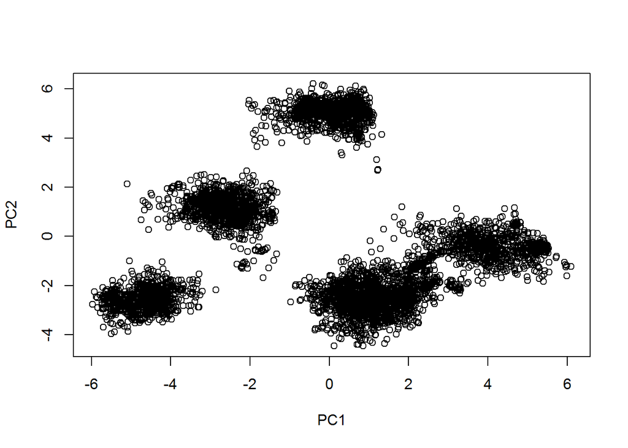

```r
plot(pca$x[,1], pca$x[,2], xlab="PC1", ylab="PC2")
```

```r
print(modelfit)
```

```
## Random Forest
##
## 5402 samples
##   52 predictor
##    5 classes: 'A', 'B', 'C', 'D', 'E'
##
## Pre-processing: centered, scaled, principal component signal extraction
## Resampling: Cross-Validated (10 fold)
## Summary of sample sizes: 4863, 4862, 4861, 4862, 4862, 4862, ...
## Resampling results across tuning parameters:
##
##   mtry  Accuracy   Kappa      Accuracy SD  Kappa SD
##    2    0.9266947  0.9072086  0.005653597  0.00718706
##   27    0.9072567  0.8826149  0.013073753  0.01653382
##   52    0.9050349  0.8798121  0.011416151  0.01443596
##
## Accuracy was used to select the optimal model using  the largest value.
## The final value used for the model was mtry = 2.
```

```r
predictions <- predict(modelfit,newdata=test)
confusionMatrix(predictions,test$classe)
```

```
## Confusion Matrix and Statistics
##
##           Reference
## Prediction   A   B   C   D   E
##          A 606   0   0   0   0
##          B   0 417   0   0   0
##          C   0   0 383   0   0
##          D   0   0   0 371   0
##          E   0   0   0   0 388
##
## Overall Statistics
##
##                Accuracy : 1
##                  95% CI : (0.9983, 1)
##     No Information Rate : 0.2799
##     P-Value [Acc > NIR] : < 2.2e-16
##
##                   Kappa : 1
##  Mcnemar's Test P-Value : NA
##
## Statistics by Class:
##
##                      Class: A Class: B Class: C Class: D Class: E
## Sensitivity            1.0000   1.0000   1.0000   1.0000   1.0000
## Specificity            1.0000   1.0000   1.0000   1.0000   1.0000
## Pos Pred Value         1.0000   1.0000   1.0000   1.0000   1.0000
## Neg Pred Value         1.0000   1.0000   1.0000   1.0000   1.0000
## Prevalence             0.2799   0.1926   0.1769   0.1714   0.1792
## Detection Rate         0.2799   0.1926   0.1769   0.1714   0.1792
## Detection Prevalence   0.2799   0.1926   0.1769   0.1714   0.1792
## Balanced Accuracy      1.0000   1.0000   1.0000   1.0000   1.0000
```

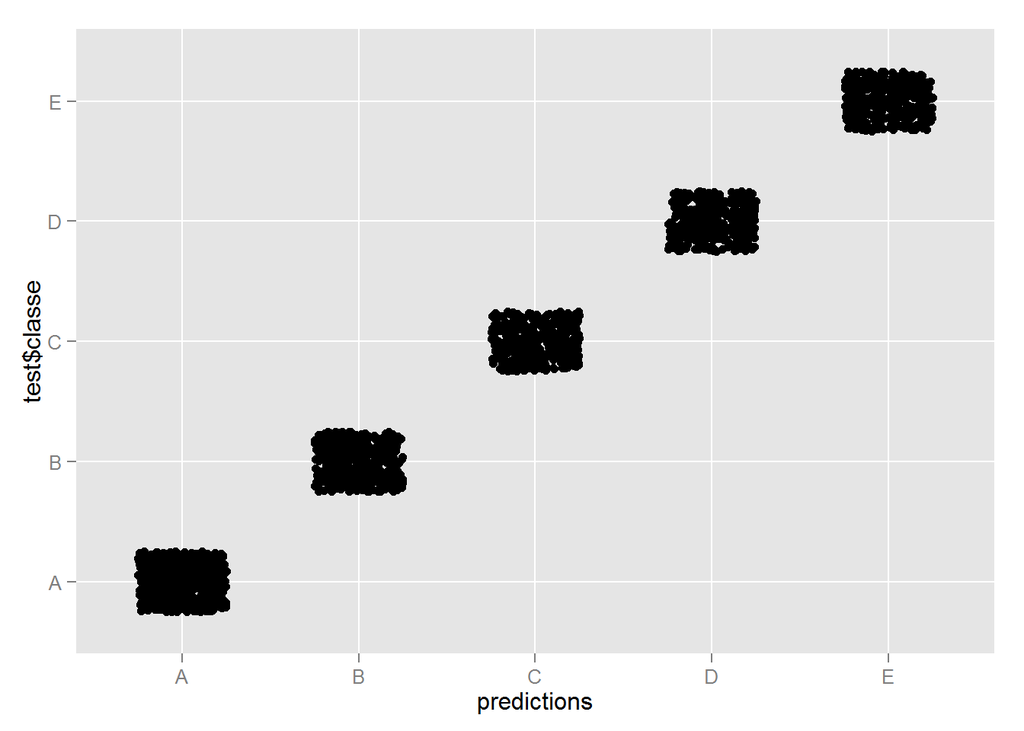

```r
pred <- data.frame(predictions,test$classe)
p <- ggplot(pred, aes(x = predictions, y = test$classe))
p <- p + geom_jitter(position = position_jitter(width = 0.25, height = 0.25))
p
```

## Predictions

- in the following, the model is used to predict 20 values from a testing set
- the prediction results are saved in 20 separate text files

```r
answers <- predict(modelfit,newdata=testing)
pml_write_files = function(x){
  n = length(x)
  for(i in 1:n){
    filename = paste0("problem_id_",i,".txt")
    write.table(x[i],file=filename,quote=FALSE,row.names=FALSE,col.names=FALSE)
  }
}

pml_write_files(answers)
```